# MSNE

with Connor T. Wiegand

## Last Time

### Matching Pennies

- There is no Nash Equilibirum in pure strategies
  - Not to be confused with subgame-perfect Nash Equilibria (SPNE), we may refer to pure strategy Nash Equilibria as **PSNE**
- What do we do?
  1. Assume Bean is playing a mixed strategy
     - Compute Sean’s expected payoffs in response to Bean
     - Use these to find when Sean could be induced to play a mixed strategy
  2. Assume Sean is playing a mixed strategy
     - Compute Bean’s expected payoffs in response to Sean
     - Use these to find when Bean could be induced to play a mixed strategy
  - When both players play (mixed) strategies that induce the other player to mix, we called this our **MSNE**

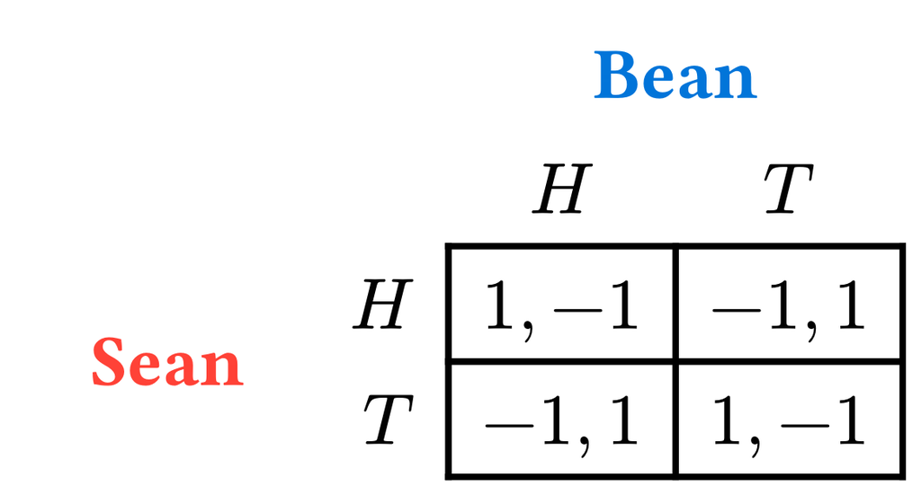

### Example 1: BoS

Let’s find all NE in BoS

- First things first: check for PSNE
  - (R,R) and (F,F) are NE
- Step 1-0
- 1-1
- Step 2-0
- 2-1
- Suppose player 2 is playing $\tau=qR+(1-q)F$
  - $E[u_1(R, \tau)] = 3q+(1-q)=1+2q$
  - $E[u_1(F, \tau)] = 0+2(1-q)=2-2q$
- Player 1 mixes when these expected payoffs are equal

$$\begin{align*}
E[u_1(R, \tau)]&=E[u_1(F, \tau)]\\
1+2q&=2-2q\\
4q&=1\\
q&=\frac{1}{4}
\end{align*}$$

- Player 1 mixes when $q=1/4$, ie when player 2 is playing $\frac{1}{4}R+\frac{3}{4}F$
- Suppose player 1 is playing $\sigma=pR+(1-p)F$
  - $E[u_2(\sigma, R)] = 2p$
  - $E[u_2(\sigma, F)] = p+3(1-p)=3-2p$
- Player 2 mixes when these expected payoffs are equal

$$\begin{align*}
E[u_2(\sigma, R)] &=E[u_2(\sigma, F)]\\
2p&=3-2p\\
4p&=3\\
p&=\frac{3}{4}
\end{align*}$$

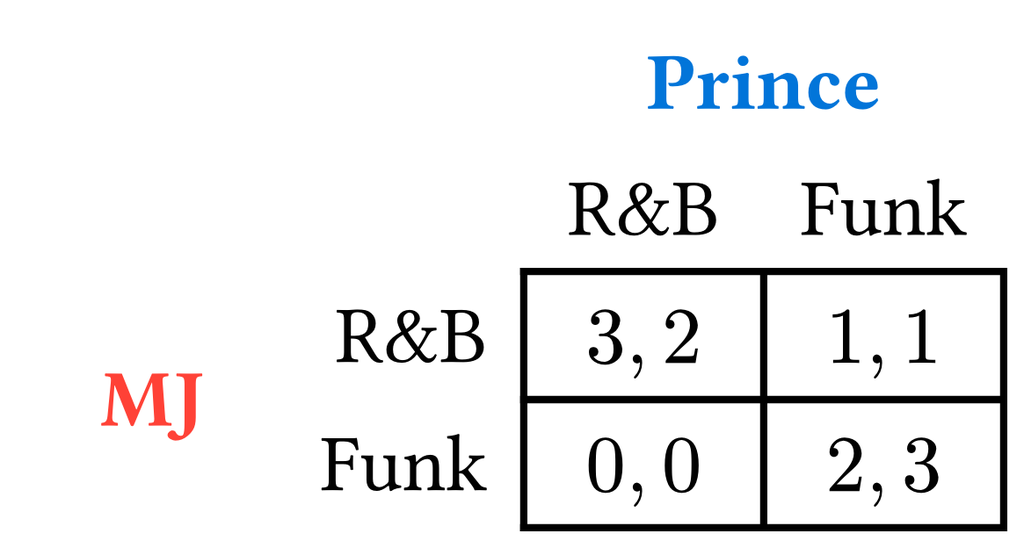

### Example 1: BoS (cont.)

- When player 1 is playing $\sigma(3/4)=(3/4)R+(1/4)F$, player 2 is indifferent between their pure strategies, so they can be induced to mix
- When player 2 is playing $\tau(1/4)=(1/4)R+(3/4)F$, player 1 is indifferent between their pure strategies, so they can be induced to mix
- So, when players are playing $\{\sigma(3/4), \tau(1/4)\}$, both players are indifferent between any other strategies they could play
  - In other words, no one can deviate for strictly higher payoffs
- Hence,
  $$\{\sigma(3/4), \tau(1/4)\}$$
  is our MSNE

## Visualizing MSNE

- Visualizing mixed strategies will give us a lot of information about our game in question
- There are two types of graphs which we are interested in drawing:
  1. Expected payoff graph
  2. Best response plot
- We will focus on first one today

### Expected Payoff Graph

- Suppose opponent is playing a mixed strategy involving only two pure strategies
  - ex: $\tau(q)=qX+(1-q) Y$
- *Idea:* graph the expected payoff of playing each of one’s pure strategies in response to this mixed strategy against the probability parameter
  - e.g. plot $E[u_i(s, \tau)]$ on the y-axis, and $q$ on the x-axis.
- Ex: For BoS, we found
  - $E[u_1(R, \tau)] = 1+2q$
  - $E[u_1(F, \tau)] = 2-2q$
- So, let’s plot each of these against $q$
  - *Note:* let’s de-clutter some notation:
    - we know we are taking expected values
    - we know the opponent is playing a mixed strategy, and the name isn’t all too important

### Expected Payoff Graph for BoS

Player 1’s expected payoff from playing …

- $R$ in response to $\tau$ is $u_1(R) = 1+2q$
- $F$ in response to $\tau$ is $u_1(F) = 2-2q$

[interactive chart not shown]

Figure 1: What do you notice? [(Sauce)](https://www.desmos.com/calculator/qlrxqp4t0h?invertedColors=true)

### BR from a graph

- Where the lines intersect = where player 1 is indifferent between playing $R$ and playing $F$
  - This is exactly $q=0.25$, like we found
- What else?
- *What happens when* $q\neq0.25$?
  - When $q<0.25$, the payoff of playing $F$ exceeds that of playing $R$
  - When $q>0.25$, the payoff of playing $R$ exceeds that of playing $F$
- With this info, we can now build player 1’s Best Response as a function of $q$:
  $$BR_1(q)=
  \begin{cases}
  F & q<0.25\\
  \{R,F\} & q=0.25\\
  R & q>0.25
  \end{cases}$$

[interactive chart not shown]

## Sketching E.P. Graphs

### Sketching E.P. Graphs

- It’s easier than you think to sketch one of these from a game table

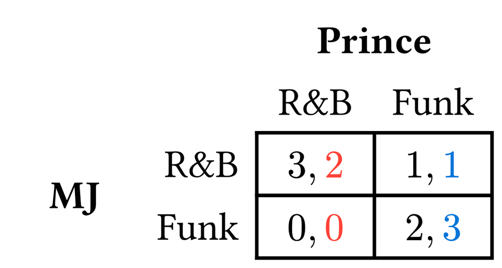

[interactive chart not shown]

- Read from bottom to top, the payoffs for each strategy match the left-to-right values on the graph

### Another Example

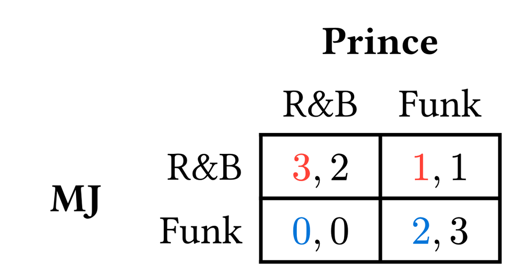

[interactive chart not shown]

- Similarly: For player 1, the payoffs for each strategy, read from right to left, match the left-to-right values on the graph

### Why?

- Our arbitrary mixed strategies simply mimic the definition of a line
- For starting point $p_1$ to end point $p_2$, a line can be parameterized according to
  $$tp_1 + (1-t)p_2$$
  for $t\in[0,1]$
- Our mixed strategies are just linear combinations of pure strategies, but I digress
- The fact that we have to read the tables “backwards” is because we put $q$ on the “first” strategy<sup>1</sup>
[^1]: For this reason, some authors choose to denote mixed strategies as $(1-q)X+qY$

## More info from E.P. Graphs

### Best response

- We already saw one connection between the the expected payoff graph for a player and the player’s BR function
- As it turns out, the entirety of a player’s best response function is baked into this graph
  - For a given $q$ value, we can trace up to the highest line on the expected payoff graph at the point $q$: this is our best response!

### The Upper Envelope

- What’s more: focus on the highest lines for any given $q$ value, and stitch these together
- This generates what is called the **Upper Envelope** for a graph, and let’s us get direct information on the best response function
- Ex: Consider the following expected payoff graph
  - Assume it’s for some player with access to strategies $X$, $Y$, and $Z$
  - In response to a strategy of the form $\sigma=pA+(1-p)B$

[interactive chart not shown]

### Using the Upper Envelope to get a BR function

- Upper Envelope
- BR function

[interactive chart not shown]

## Dominance and Non-Rationalizability in Expected Payoff Graphs

### Bigger example

- Let’s take a look at the following example – it’s big
- Assume that you drew this graph from some payoff matrix

[interactive chart not shown]

### Observations

The fact that some lines sit completely (or mostly) above each other tell us information about dominated strategies for player 1 - $A$ is strictly dominated by $B$ and $D$

- $B$ is weakly dominated by $D$
- $C$ is strictly dominated by $D$ and $E$
- What about $E$?<sup>1</sup>
  - Will you ever play it?
    - No, not in upper envelope (so not in BR function)
  - Does anything dominate
    - Also no
  - Can we get rid of it?
[^2]: This was the yellow $G$ in class

### Recall

- At the end of week 3 (slide deck 6), we saw the following information
- Sd-6
- Def [Version 1.0]: A (pure) strategy $\tilde{s}\in S_{i}$ is said to be Never a Best Response provided that $\tilde{s}\notin BR_{i}(s_{-i})$ for any $s_{-i}\in S_{-i}$
- How is this related to strict/weak domination?
- **Fact:** a strictly dominated strategy is never a best response
  - Why?
- Do we want to eliminate NBRs *a la* IDSDS?
  - No, at least not using this definition
  - We will return to this later, when we resume mixed strategies
- Now, it’s later

### Updated Definition

- Def [Version 2.0]: A strategy is said to be **Never a Best Response** provided that it is never a component of a player’s best response function — *taking into account mixed strategies*
  - In other words, a strategy is an NBR provided that it isn’t in the upper envelope of an agent’s expected payoff graph
- For the updated definition, I will also use NBR interchangeably with **non-rationalizable**
  - We could say an agent’s strategy is rationalizable if it *is* in the upper envelope (/ is a component of the agent’s best response function)

### The importance of rationalizability

- With this updated definition, we actually *can* eliminate NBRs iteratively – preserving all of the properties of IDSDS
  - However, since we are now in mixed strategy world, it is often not practical to do so
- In fact, eliminating NBR’s in this manner is equivalent to iteratively eliminating strictly dominated strategies
  - NBR $\implies$ strictly dominated. The strategy may be dominated *by a mixed strategy*
- Once again: the expected payoff graphs give us a lot of information

### Using the Upper Envelope: An example

- The game:

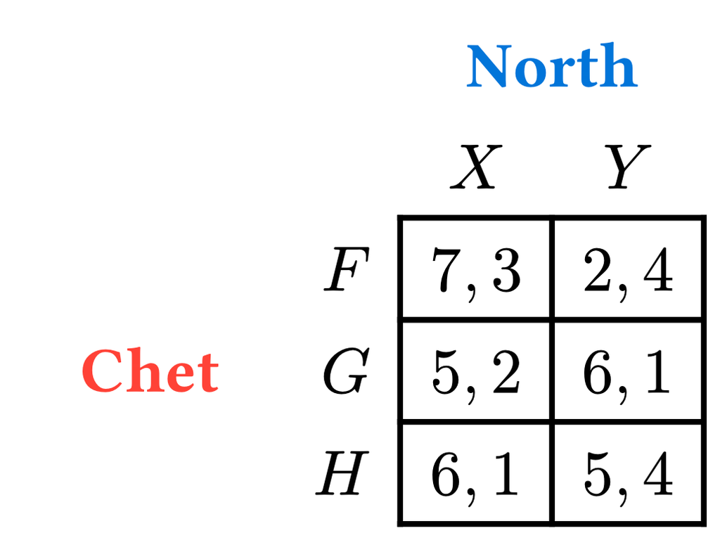

- We have seen this game before. Recall:
  - $BR_1(X)=F$
  - $BR_1(Y)=G$
- It is tempting to want to say that $H$ is Never a Best Response, because player 1 would always rather play something other than $H$ in response to a pure strategy
- Should player 1 ever play $H$?

### Example, continued

- Game
- E.P. Graph
- Upper Envelope
- BR function

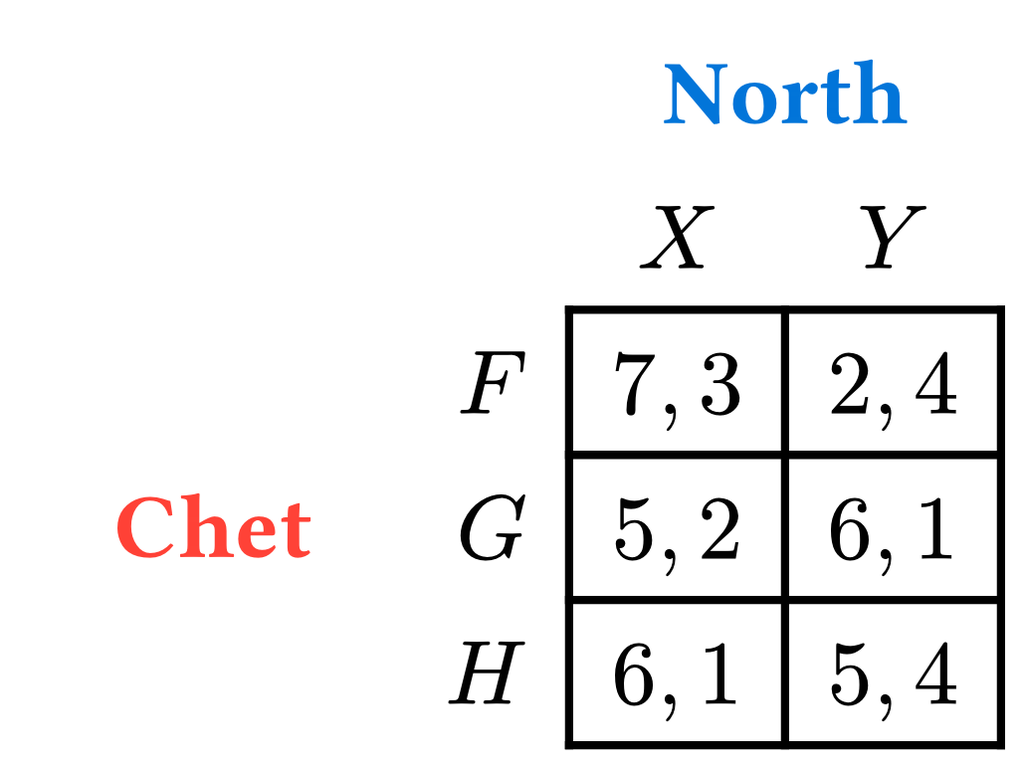

[interactive chart not shown]

$$BR_1(q)=
\begin{cases}
G & q < q_1^*\\
{G, H} & q = q_1^*\\
H & q_1^*\le q \le q_2^*\\
{H, F} & q = q_2^*\\
F & q>q_2^*
\end{cases}$$